# act_report

## Insights from WeRateDogs Data

A cleaned dataset of dog ratings from WeRateDogs was used to answer the following questions:

**1. What are the top five popular dog breeds based on the average favorite count?**

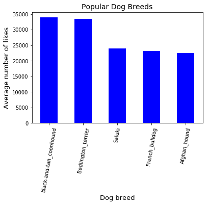

As can be seen from the column chart above, the most popular breed in the data is the *black-and-tan_coonhound* with an average of 33911 likes followed by the *Bedlington_terrier* with a mean of 33445 likes. The other three breeds making up the top five are *Saluki* (with an average of 24060 likes), *French_bulldog* (an average of 23118 likes) and *Afghan_hound* (with an average of 22451 likes).

**2. What is the most common source of dog rating?**

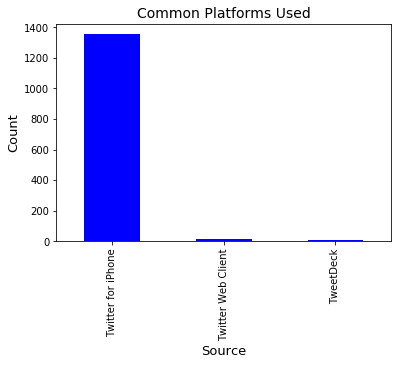

The most common source of dog rating tweets is *"Twitter for iPhone"*, with a total of 1354 tweets followed by *"Twitter Web Client"* with 14 tweets. *"TweetDeck"* comes third with a total of 8 tweets. As can be seen from the column chart above, this seems to suggest that *"Twitter for iPhone"* is by far the most popular platform used for the dog rating tweets.

**3. On average, how has the number of dog rating retweets changed from the year 2015 to the year 2017?**

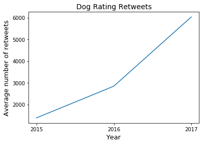

Between the years 2015 and 2017, the number of dog rating retweets increased by over 300%, from an average of about 1379 retweets in the year 2015 to an average of about 6031 retweets in the year 2017. The year 2016 had an average of 2843 retweets. This trend is presented in the plot above.

**4. Which dog stage has the highest median rating?**

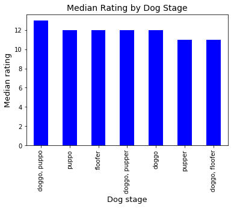